# Solar PV Exports and Installed Capacity Analysis (10/28/2026)

Study area: North America and South America (Totally 15 countries)

```python
# Import packages and data
import pandas as pd
import matplotlib.pyplot as plt
from pathlib import Path

df = pd.read_csv("../data/Processed/solar_country_year_python_2018_2025.csv")
df.head()
```

|  | Area | Study_scope | Year | China_panel_exports_USD | China_panel_exports_MW | CleanTech_solarPV_USD | CleanTech_alltech_USD | PV_installed_capacity_MW | PV_generation_GWh | Population | PV_capacity_additions_MW | PV_installed_W_per_person |
| --- | --- | --- | --- | --- | --- | --- | --- | --- | --- | --- | --- | --- |
| 0 | Canada | North America | 2018 | 48086354.0 | 181.13 | 48121174 | 324210505 | 2631.0 | 3491.0 | 37072620.0 | NaN | 70.968817 |
| 1 | Canada | North America | 2019 | 62046149.0 | 235.58 | 62046216 | 501304576 | 2828.0 | 3752.0 | 37618495.0 | 197.0 | 75.175788 |
| 2 | Canada | North America | 2020 | 72110171.0 | 310.85 | 72110171 | 523513306 | 3068.0 | 4072.0 | 38028638.0 | 240.0 | 80.676042 |
| 3 | Canada | North America | 2021 | 59623578.0 | 222.12 | 59623578 | 857777248 | 3854.0 | 5115.0 | 38239864.0 | 786.0 | 100.784877 |
| 4 | Canada | North America | 2022 | 24636922.0 | 89.66 | 77003130 | 1107503288 | 4322.0 | 5737.0 | 38950132.0 | 468.0 | 110.962397 |

# Figure 1

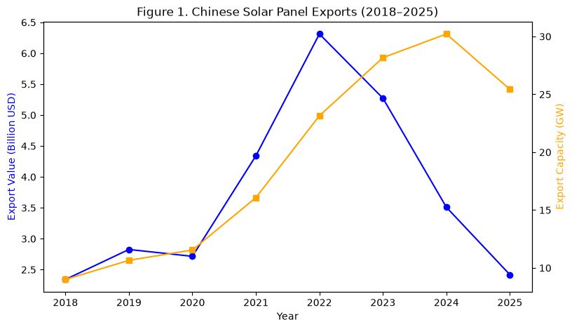

```python
# Output the first figure: China's Solar Panel Exports (2018-2025)

annual = df.groupby('Year')[['China_panel_exports_USD', 'China_panel_exports_MW']].sum()

fig, ax1 = plt.subplots(figsize=(9, 5))

ax1.plot(annual.index,
         annual['China_panel_exports_USD'] / 1e9,
         marker='o',
         color='blue',
         label='Export Value')
ax1.set_xlabel('Year')
ax1.set_ylabel('Export Value (Billion USD)',
               color='blue')

ax2 = ax1.twinx()
ax2.plot(annual.index,
         annual['China_panel_exports_MW'] / 1000,
         marker='s',
         color='orange',
         label='Export Capacity')
ax2.set_ylabel('Export Capacity (GW)',
               color='orange')

plt.title('Figure 1. Chinese Solar Panel Exports (2018–2025)')
plt.show()
```

Figure 1 compares the annual export value (billion USD) and exported panel capacity (GW) to the 15 countries.

Annual exports to the study countries increased in capacity from 9.0 GW in 2018 to 30.2 GW in 2024, before falling to 25.4 GW in 2025. However, export value peaked earlier, at about $6.31 billion in 2022, and then declined.

# Figure 2

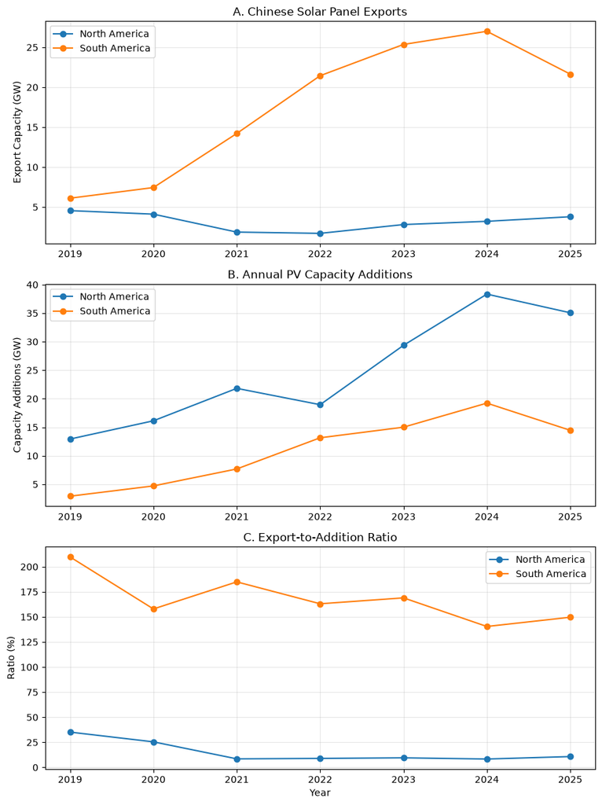

```python
# Output the second figure: North vs. South America: Exports and Installations
region = df.groupby(['Year', 'Study_scope'])[
    ['China_panel_exports_MW', 'PV_capacity_additions_MW']
].sum(min_count=1).reset_index()

# Calculate ratio
region['Ratio'] = (
    region['China_panel_exports_MW'] /
    region['PV_capacity_additions_MW'] * 100
)

# Remove 2018 because capacity additions are missing
region = region[region['Year'] >= 2019]

fig, axes = plt.subplots(3, 1, figsize=(9, 12))

for name, data in region.groupby('Study_scope'):
    axes[0].plot(data['Year'],
                 data['China_panel_exports_MW'] / 1000,
                 marker='o',
                 label=name)
    axes[1].plot(data['Year'],
                 data['PV_capacity_additions_MW'] / 1000,
                 marker='o',
                 label=name)
    axes[2].plot(data['Year'],
                 data['Ratio'],
                 marker='o',
                 label=name)

axes[0].set_title('A. Chinese Solar Panel Exports')
axes[0].set_ylabel('Export Capacity (GW)')

axes[1].set_title('B. Annual PV Capacity Additions')
axes[1].set_ylabel('Capacity Additions (GW)')

axes[2].set_title('C. Export-to-Addition Ratio')
axes[2].set_ylabel('Ratio (%)')
axes[2].set_xlabel('Year')

for ax in axes:
    ax.legend()
    ax.grid(alpha=0.3)

plt.tight_layout()
plt.show()
```

In Figure 2, the three aligned panels show (A) exported panel capacity, (B) annual net changes in PV installed capacity, and (C) the export-to-addition ratio. Annual additions are missing in 2018, so this comparison starts in 2019.

In 2024, Chinese panel exports reached 27.0 GW to South America versus 3.2 GW to North America. Yet North America's annual net installed-capacity increase was larger (38.3 GW) than South America's (19.2 GW). This shows the two regions have different patterns of direct imports from China and domestic PV deployment.

# Figure 3

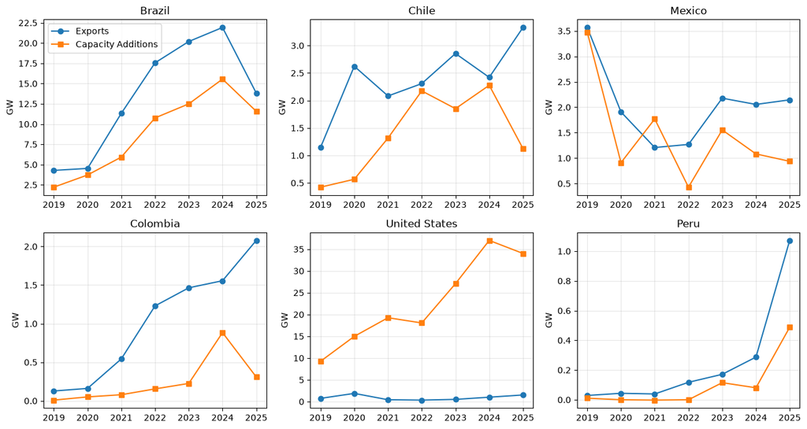

```python
import matplotlib.pyplot as plt

countries = ['Brazil', 'Chile', 'Mexico',
             'Colombia', 'United States', 'Peru']

fig, axes = plt.subplots(2, 3, figsize=(13, 7))

for ax, country in zip(axes.flat, countries):
    data = df[(df['Area'] == country) & (df['Year'] >= 2019)]

    ax.plot(data['Year'],
            data['China_panel_exports_MW'] / 1000,
            marker='o', label='Exports')

    ax.plot(data['Year'],
            data['PV_capacity_additions_MW'] / 1000,
            marker='s', label='Capacity Additions')

    ax.set_title(country)
    ax.set_ylabel('GW')
    ax.grid(alpha=0.3)

axes[0, 0].legend()
plt.tight_layout()
plt.show()
```

In Figure 3, the small charts allow each country to have its own y-axis scale. Within each country, the two lines use the same GW unit.

The countries do not follow one common pattern. For example, in 2025, the United States recorded around 34.0 GW of annual PV net additions but only 1.53 GW of direct Chinese panel exports. Brazil, by contrast, received about 13.82 GW of Chinese panel exports and added 11.58 GW of PV capacity.

# Figure 4

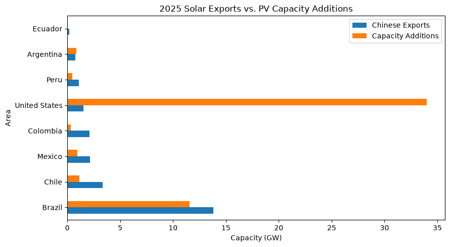

```python
data = df[df['Year'] == 2025]
data = data.nlargest(8, 'China_panel_exports_MW')

data = data.set_index('Area')

data[['China_panel_exports_MW',
      'PV_capacity_additions_MW']].div(1000).plot(
    kind='barh',
    figsize=(9, 5)
)

plt.xlabel('Capacity (GW)')
plt.title('2025 Solar Exports vs. PV Capacity Additions')
plt.legend(['Chinese Exports', 'Capacity Additions'])
plt.tight_layout()
plt.show()
```

Figure 4 shows the two measures for the eight largest Chinese panel export destinations in 2025, including Ecuador, Argentina, Peru, United States, Colombia, Mexico, Chile, Brazil.

Brazil was the largest direct destination in this 2025 subset, followed by Chile and Mexico. The United States having much larger PV additions than directly recorded Chinese panel exports.